# Random Forest

## Optimal number of variables

As a first step toward the improvement of our Random Forest model, we will try more variable at each step. As a matter of fact, we introduced a lot of variables due to the one-hot encoding that should be more taken into account when running our RF algorithm.

To do so, we will iterate over a range of variable number and plot the OOB error rate.

```r
oob_per_mtry <- function(mtry){
  print(mtry)
  model = randomForest(formula = y ~ age + balance + duration + campaign + previous + poutcome_failure + poutcome_success + poutcome_unknown + job_admin + job_blue_collar + job_entrepreneur + job_housemaid + job_management + job_retired + job_self_employed + job_services + job_student + job_technician + job_unemployed + job_unknown + marital_divorced + marital_married + marital_single + education_primary + education_secondary + education_tertiary + education_unknown + default_no + default_yes + housing_no + housing_yes + loan_no + loan_yes + month_apr + month_aug + month_dec + month_feb + month_jan + month_jul + month_jun + month_mar + month_may + month_nov + month_oct + month_sep + pdays_never + pdays_u3m + pdays_u6m + pdays_u9m + pdays_u12m + pdays_u18m + pdays_o18m, data=trainingData, ntree=500, mtry=mtry)

  return(model$err.rate[498,1])
}

mtry_vals = c(1:54)
oob_vals = lapply(mtry_vals, oob_per_mtry)
```

```
## [1] 1
## [1] 2
## [1] 3
## [1] 4
## [1] 5
## [1] 6
## [1] 7
## [1] 8
## [1] 9
## [1] 10
## [1] 11
## [1] 12
## [1] 13
## [1] 14
## [1] 15
```

[output cut: 38 more lines]

```
## [1] 54
```

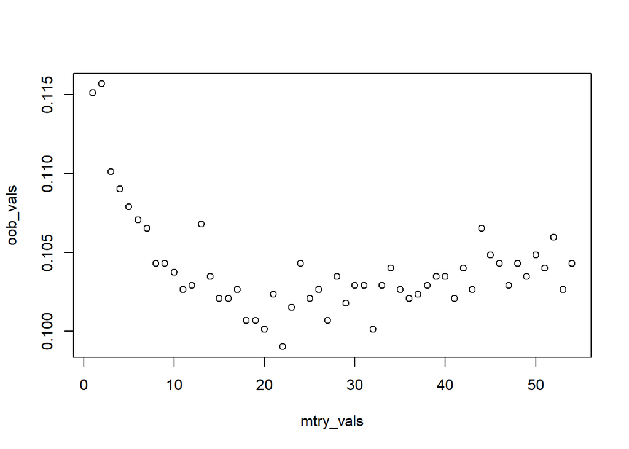

```r
plot(mtry_vals, oob_vals)
```

We’ll then recompute our Random Forest model with this *mtry* paramter:

```r
model = randomForest(formula = y ~ age + balance + duration + campaign + previous + poutcome_failure + poutcome_success + poutcome_unknown + job_admin + job_blue_collar + job_entrepreneur + job_housemaid + job_management + job_retired + job_self_employed + job_services + job_student + job_technician + job_unemployed + job_unknown + marital_divorced + marital_married + marital_single + education_primary + education_secondary + education_tertiary + education_unknown + default_no + default_yes + housing_no + housing_yes + loan_no + loan_yes + month_apr + month_aug + month_dec + month_feb + month_jan + month_jul + month_jun + month_mar + month_may + month_nov + month_oct + month_sep + pdays_never + pdays_u3m + pdays_u6m + pdays_u9m + pdays_u12m + pdays_u18m + pdays_o18m, data=trainingData, ntree=500, mtry=30)
print(model)
```

```
##
## Call:
##  randomForest(formula = y ~ age + balance + duration + campaign +      previous + poutcome_failure + poutcome_success + poutcome_unknown +      job_admin + job_blue_collar + job_entrepreneur + job_housemaid +      job_management + job_retired + job_self_employed + job_services +      job_student …
##                Type of random forest: classification
##                      Number of trees: 500
## No. of variables tried at each split: 30
##
##         OOB estimate of  error rate: 10.35%
## Confusion matrix:
##      0   1 class.error
## 0 3083 107  0.03354232
## 1  266 149  0.64096386
```

```r
pred = predict(model, testData, type="class")
table(pred=pred, true=testData$y)
```

```
##     true
## pred   0   1
##    0 776  63
##    1  22  41
```

```r
paste(mean(pred==testData$y), bal_accuracy_vec(pred, truth=testData$y, estimator="binary"))
```

```
## [1] "0.905764966740576 0.683330923462502"
```

```r
tab = confusionMatrix(pred, testData$y)
tab$table
```

```
##           Reference
## Prediction   0   1
##          0 776  63
##          1  22  41
```

```r
tab$byClass['F1']
```

```
##        F1
## 0.9480757
```

Because we had very little effect on accuracy using the number of variable optimization, we tried to use the dataset without the one-hot encoding.

# Without one-hot

## Default run

```r
set.seed(123)
#Training & Test Datasets
deposit_yes <- data[which(data$y == "yes"), ]  # all yes's of target class
deposit_no <- data[which(data$y ==  "no"), ]  # all no's of target class

deposit_yes_training_rows <- sample(1:nrow(deposit_yes), 0.8*nrow(deposit_yes))  #randomly choosing 80% observations of yes class
deposit_no_training_rows <- sample(1:nrow(deposit_no), 0.8*nrow(deposit_no))  #randomly choosing 80% observations of no class
training_yes <- deposit_yes[deposit_yes_training_rows, ]
training_no <- deposit_no[deposit_no_training_rows, ]
trainingData_withcat <- rbind(training_yes, training_no)  #combining chosen observations

test_yes <- deposit_yes[-deposit_yes_training_rows, ]
test_no <- deposit_no[-deposit_no_training_rows, ]
testData_withcat <- rbind(test_yes, test_no)  #combining chosen observations

summary(trainingData_withcat)
```

```
##        ID            age              job          marital         education
##  Min.   :   1   Min.   :19   management :771   divorced: 431   primary  : 545
##  1st Qu.:1144   1st Qu.:33   blue-collar:757   married :2218   secondary:1838
##  Median :2274   Median :39   technician :634   single  : 962   tertiary :1079
##  Mean   :2270   Mean   :41   admin.     :376                   unknown  : 149
##  3rd Qu.:3394   3rd Qu.:48   services   :338
##  Max.   :4521   Max.   :87   retired    :177
##                              (Other)    :558
##  default       balance        housing     loan          month
##  no :3550   Min.   :-2082.0   no :1554   no :3048   may    :1112
##  yes:  61   1st Qu.:   65.5   yes:2057   yes: 563   jul    : 560
##             Median :  443.0                         aug    : 508
##             Mean   : 1414.7                         jun    : 410
##             3rd Qu.: 1512.0                         nov    : 321
##             Max.   :27733.0                         apr    : 236
##                                                     (Other): 464
##     duration         campaign                  pdays         previous
##  Min.   :   4.0   Min.   : 1.000   Never contacted:2954   Min.   : 0.0000
##  1st Qu.: 105.0   1st Qu.: 1.000   Under 3months  :  52   1st Qu.: 0.0000
##  Median : 185.0   Median : 2.000   Under 6months  : 217   Median : 0.0000
##  Mean   : 260.1   Mean   : 2.781   Under 9months  : 156   Mean   : 0.5442
##  3rd Qu.: 325.0   3rd Qu.: 3.000   Under 1yr      : 167   3rd Qu.: 0.0000
##  Max.   :2087.0   Max.   :32.000   Under 1.5yrs   :  58   Max.   :23.0000
##                                    Over 1.5yrs    :   7
##     poutcome      y
##  failure: 400   no :3196
##  other  :   0   yes: 415
##  success: 102
##  unknown:3109
##
##
##
```

To get colnames

```
## ID + age + job + marital + education + default + balance + housing + loan + month + duration + campaign + pdays + previous + poutcome + y +
```

```r
rf = randomForest(formula = y ~ age + job + marital + education + default + balance + housing + loan + month + duration + campaign + pdays + previous + poutcome, data=trainingData_withcat)
print(rf)
```

```
##
## Call:
##  randomForest(formula = y ~ age + job + marital + education +      default + balance + housing + loan + month + duration + campaign +      pdays + previous + poutcome, data = trainingData_withcat)
##                Type of random forest: classification
##                      Number of trees: 500
## No. of variables tried at each split: 3
##
##         OOB estimate of  error rate: 9.91%
## Confusion matrix:
##       no yes class.error
## no  3105  91  0.02847309
## yes  267 148  0.64337349
```

```r
pred = predict(rf, testData_withcat, type="class")
table(pred=pred, true=testData_withcat$y)
```

```
##      true
## pred   no yes
##   no  769  64
##   yes  30  40
```

```r
paste(mean(pred==testData_withcat$y), bal_accuracy_vec(pred, truth=testData_withcat$y, estimator="binary"))
```

```
## [1] "0.895902547065338 0.67353422547415"
```

```r
tab = confusionMatrix(pred, testData_withcat$y)
tab$table
```

```
##           Reference
## Prediction  no yes
##        no  769  64
##        yes  30  40
```

```r
tab$byClass['F1']
```

```
##       F1
## 0.942402
```

```r
paste(mean(pred==testData_withcat$y), bal_accuracy_vec(pred, truth=testData_withcat$y, estimator="binary"))
```

```
## [1] "0.895902547065338 0.67353422547415"
```

A note for the reader: it would have been easier to run the Random Forest computation before one-hot encoding. But we made the choice to first prepare the data with one-hot, thus we prefered the report to follow our scienfitic reasoning instead of directly following the optimal path.

## Optimal number of variables

```r
oob_per_mtry <- function(mtry){
  print(mtry)
  model = randomForest(formula = y ~ age + job + marital + education + default + balance + housing + loan + month + duration + campaign + pdays + previous + poutcome, data=trainingData_withcat, ntree=500, mtry=mtry)

  return(model$err.rate[498,1])
}

mtry_vals = c(1:14)
oob_vals = lapply(mtry_vals, oob_per_mtry)
```

```
## [1] 1
## [1] 2
## [1] 3
## [1] 4
## [1] 5
## [1] 6
## [1] 7
## [1] 8
## [1] 9
## [1] 10
## [1] 11
## [1] 12
## [1] 13
## [1] 14
```

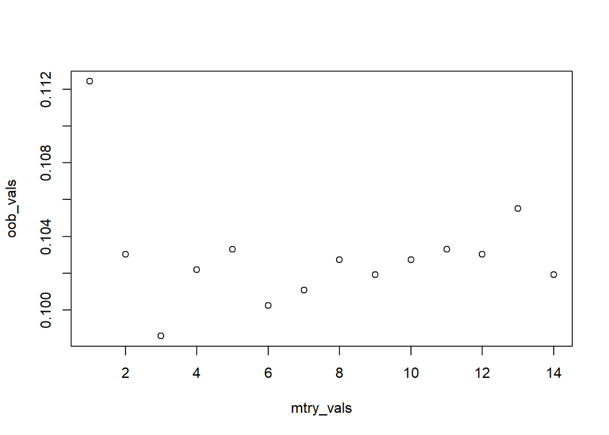

```r
plot(mtry_vals, oob_vals)
```

```r
rf = randomForest(formula = y ~ age + job + marital + education + default + balance + housing + loan + month + duration + campaign + pdays + previous + poutcome, data=trainingData_withcat, mtry=3)
print(rf)
```

```
##
## Call:
##  randomForest(formula = y ~ age + job + marital + education +      default + balance + housing + loan + month + duration + campaign +      pdays + previous + poutcome, data = trainingData_withcat,      mtry = 3)
##                Type of random forest: classification
##                      Number of trees: 500
## No. of variables tried at each split: 3
##
##         OOB estimate of  error rate: 10.02%
## Confusion matrix:
##       no yes class.error
## no  3099  97  0.03035044
## yes  265 150  0.63855422
```

```r
pred = predict(rf, testData_withcat, type="class")
table(pred=pred, true=testData_withcat$y)
```

```
##      true
## pred   no yes
##   no  770  66
##   yes  29  38
```

```r
paste(mean(pred==testData_withcat$y), bal_accuracy_vec(pred, truth=testData_withcat$y, estimator="binary"))
```

```
## [1] "0.894795127353267 0.66454462308655"
```

```r
tab = confusionMatrix(pred, testData_withcat$y)
tab$table
```

```
##           Reference
## Prediction  no yes
##        no  770  66
##        yes  29  38
```

```r
tab$byClass['F1']
```

```
##       F1
## 0.941896
```

## Variable importance

```r
rf = randomForest(formula = y ~ age + job + marital + education + default + balance + housing + loan + month + duration + campaign + pdays + previous + poutcome, data=trainingData_withcat, mtry=3, importance=TRUE)
importance(rf)
```

```
##                  no         yes MeanDecreaseAccuracy MeanDecreaseGini
## age       15.075366  2.86904379            15.338904        72.751438
## job       10.737474 -2.22924654             8.423706        58.307721
## marital    6.488813  1.40463863             6.861410        19.553470
## education  7.029521 -0.71634301             5.994078        22.031086
## default    3.464701 -0.01250191             3.291456         2.447049
## balance    1.708280 -0.19498159             1.415510        74.895223
## housing   13.415316  1.16447962            12.992600        12.706834
## loan       4.295475  1.87108268             4.636079         7.539584
## month     39.938719 12.87613141            40.572715        92.556817
## duration  46.749503 85.54914629            76.726525       212.370758
## campaign   3.704415  1.28981566             4.019985        30.331251
## pdays     17.567549  8.86085368            19.850434        26.590757
## previous  11.709991 10.24988901            13.554176        21.749874
## poutcome  18.525872 31.46485573            29.798269        36.870070
```

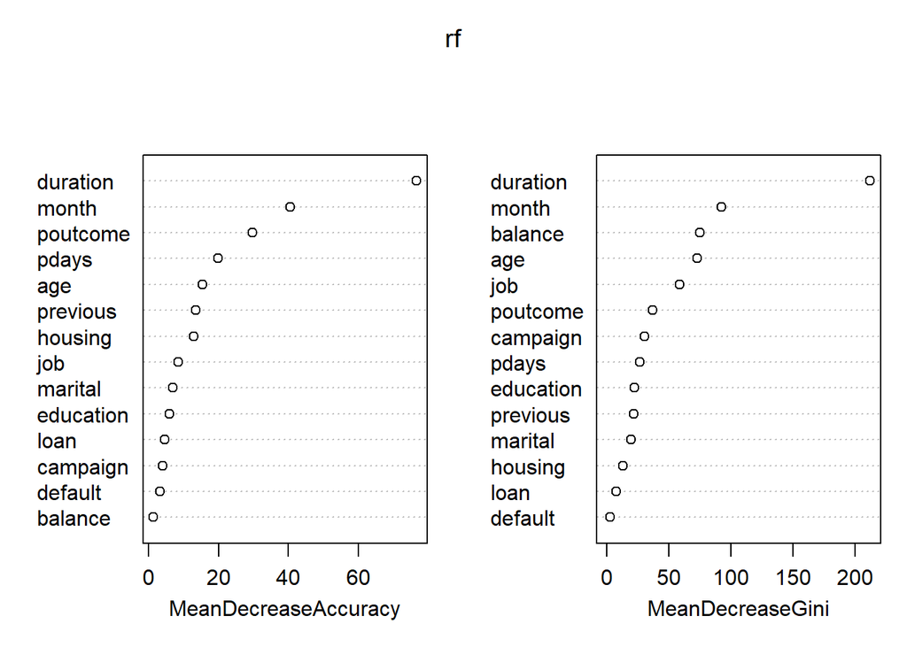

```r
varImpPlot(rf)
```

From far, the duration of the call is the most important variable which makes sense: the more time a client stays in the call with the salesperson, the more chances he has to actually take the loan.

## Tree number optimization

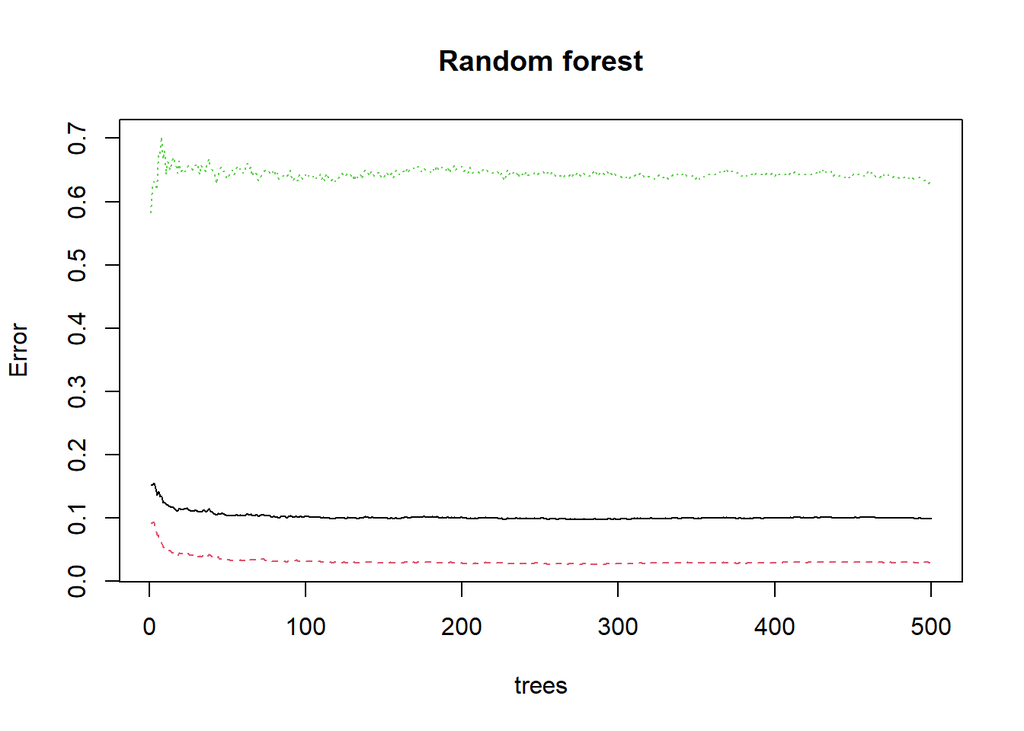

```r
plot(rf, main="Random forest")
```

```r
optimal_ntree <- function(ntree){
  # Averages on 10 runs
  print(ntree)
  scores = c()
  for(i in 1:10){
      rf = randomForest(formula = y ~ age + job + marital + education + default + balance + housing + loan + month + duration + campaign + pdays + previous + poutcome, data=trainingData_withcat, ntree=ntree, mtry=3)
    scores = c(scores, min(rf$err.rate[,1]))
  }
  print(scores)

  return(mean(scores))
}
```

```r
ntrees = seq(100, 3000, by=150)
ntrees_scores = lapply(ntrees, optimal_ntree)
```

```
## [1] 100
##  [1] 0.10468014 0.10024924 0.09997231 0.09914151 0.10108003 0.10191083
##  [7] 0.10052617 0.10329549 0.10135696 0.10384935
## [1] 250
##  [1] 0.09858765 0.09692606 0.09775685 0.09775685 0.09997231 0.10052617
##  [7] 0.10052617 0.09858765 0.09914151 0.09775685
## [1] 400
##  [1] 0.09471061 0.10191083 0.09775685 0.09831072 0.09803379 0.09969538
##  [7] 0.09747992 0.09554140 0.09637220 0.09692606
## [1] 550
##  [1] 0.09803379 0.09997231 0.09803379 0.09969538 0.09831072 0.09747992
##  [7] 0.10080310 0.09803379 0.09803379 0.09803379
## [1] 700
##  [1] 0.09747992 0.09886458 0.09637220 0.09886458 0.09747992 0.09747992
##  [7] 0.09914151 0.10135696 0.10052617 0.09803379
```

[output cut: 45 more lines]

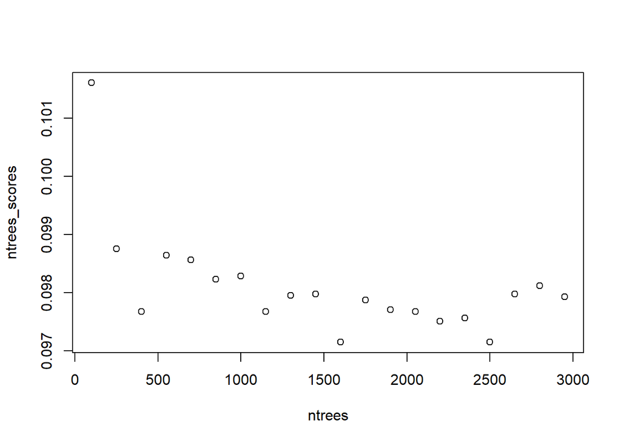

```r
plot(ntrees, ntrees_scores)
```

```r
rf = randomForest(formula = y ~ age + job + marital + education + default + balance + housing + loan + month + duration + campaign + pdays + previous + poutcome, data=trainingData_withcat, mtry=3, ntree=2000)
print(rf)
```

```
##
## Call:
##  randomForest(formula = y ~ age + job + marital + education +      default + balance + housing + loan + month + duration + campaign +      pdays + previous + poutcome, data = trainingData_withcat,      mtry = 3, ntree = 2000)
##                Type of random forest: classification
##                      Number of trees: 2000
## No. of variables tried at each split: 3
##
##         OOB estimate of  error rate: 9.8%
## Confusion matrix:
##       no yes class.error
## no  3108  88  0.02753442
## yes  266 149  0.64096386
```

We then use this Random Forest to predict the test data:

```r
pred = predict(rf, testData_withcat, type="class")
table(pred=pred, true=testData_withcat$y)
```

```
##      true
## pred   no yes
##   no  770  66
##   yes  29  38
```

```r
paste(mean(pred==testData_withcat$y), bal_accuracy_vec(pred, truth=testData_withcat$y, estimator="binary"))
```

```
## [1] "0.894795127353267 0.66454462308655"
```

```r
tab = confusionMatrix(pred, testData_withcat$y)
tab$table
```

```
##           Reference
## Prediction  no yes
##        no  770  66
##        yes  29  38
```

```r
tab$byClass['F1']
```

```
##       F1
## 0.941896
```